# Biological Programming: R Basics

Yuanchao Zhang, Deanne Taylor, and Joe Dybas

1/3/2018

In this write-up, we are going to set up R and RStudio on your computer. After getting R up and running, we will briefly go through the basic syntax and data types of R programming language. Then, we are going to learn how to use R packages and create R Markdown files. Then, we are going to go through the basic operations of R programming by analyzing a simple biological dataset. Finally, we conclude the required section by discussing the advantages of using R for data analysis comparing to Excel.

# Install R programming language

1. Go to https://www.r-project.org/.
2. Click `download R` in the `Getting Started` section.

[figure not shown]

3. Click https://cloud.r-project.org/, the first link under **0-Cloud**. The URLs to the mirrors of Comprehensive R Archive Network (CRAN) are listed in this page. A mirror is a replicate of the contents of the main server, of which the URL is http://cran.r-project.org. Therefore, you can choose any of the URLs listed if you want.

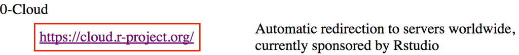

4. Choose the download link based on your operating system.
   - Linux: Choose your Linux distribution and follow the installation instructions.
   - Mac OS X: Download `R-3.4.3.pkg`. Open the downloaded file to install.
   - Windows: Choose `base`, then `Download R 3.4.3 for Windows`. Open the downloaded file to install.

# Install RStudio

1. Go to https://www.rstudio.com/products/rstudio/download/#download.
2. Choose the installer to download based on your operating system. For Linux users, check if you are running 32-bit or 64-bit system.
3. Open the downloaded file to install. If you are running Ubuntu, you might need to install by using the `gdebi` utility, and you can find more information at https://medium.com/@GalarnykMichael/install-r-and-rstudio-on-ubuntu-12-04-14-04-16-04-b6b3107f7779.

Note on 32-bit and 64-bit: Most of the time, we only need to know this information when trying to install or run some software. 32-bit or 64-bit refers to the size of register in the central processing unit (CPU). 32-bit system allows direct access of $2^{32}$ bytes of memory, and [64-bit](https://en.wikipedia.org/wiki/64-bit_computing) allows direct access of $2^{64}$ bytes of memory.

# Run RStudio

1. Open the installed RStudio. If all went well, there should no error message, and there should be several panes.
2. Find the pane with the `Console` tab in it and select that tab, which is the left pane by default if you have not opened any script yet. The console runs an R programming language interpreter, which executes the R code for you.

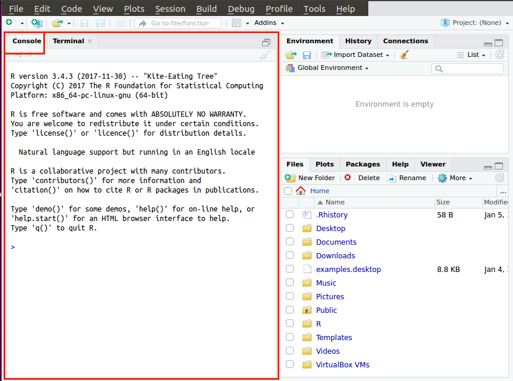

3. Select the `Console` pane by clicking on its inner area. You should see a cursor blinking after the prompt `>`.
4. Type `print("Hello World!")` and hit enter. You should see the following prompt in the next line `[1] "Hello World!"`. An R base function `print()` is called with the positional parameter `"Hello World"`. After this line of code is executed, the parameter is printed by the computer to the console.

[figure not shown]

Even though this line of code is simple, there are actually many things happened behind the scene:

1. RStudio starts running. RStudio is an integrated development environment (IDE) for R programming language. RStudio is written mainly in Java, C++, and JavaScript. You can look at their source code stats if you are interested by going to the following link, https://github.com/rstudio/rstudio.
2. RStudio runs R programming language interpreter and shows its output in the `Console` tab. The R programming language interpreter is basically an infinite loop with memory of executions within the same session:
   - Prompt `>`.
   - Takes in code expression.
   - Executes the code expression. When execution is done, prompt `>` again and ready for the next code expression. However, if one or more variables are created or updated, the interpreter will remember them.

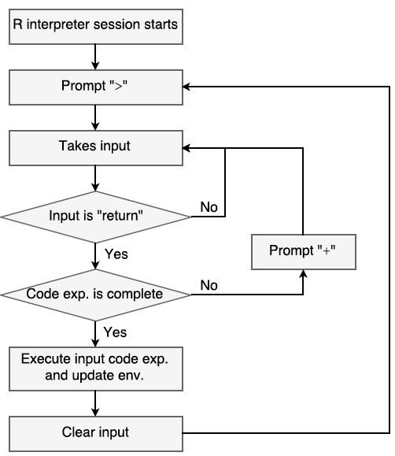

> R interpreter loop

3. You typed in `print("Hello World!")` and “enter” in the R interpreter.
4. When R interpreter sees the “enter”, it checks your code before the “enter”. If you wonder why this is necessary, try type `print("Hello World!"` and “enter”. Note that the `)` is missing at the end. Then, at the next line with the prompt `+`, type `)` and “enter”. The `)` in the second line completes the code expression, and the R interpreter starts executing the code expression.
5. R interpreter found a complete code expression and starts executing the code without the “enter”.
6. R interpreter starts executing `print("Hello World!")`, which is a function to print data out. **At this point**, the prompt `[1] "Hello World!"` is printed out. Question: why is there `[1]` before `"Hello World"`? Hint: try to run `print(1:100)`, where `1:100` creates a vector of integers from 1 to 100.
7. `print("Hello World!")` function returns `"Hello World!"`, but there is no variable assigned to that return value. Try to run `myVariable <- print("Hello World!")` and see what the value is stored in `myVariable`. You can see it either by typing `myVariable` and “enter” in the console, or find it in the `Environment` tab of another pane. Environment is basically a collection of variables.
8. R interpreter evaluation loop resumes running to take in the next code expression. If you would like to see the suspension of R interpreter evaluation loop, try to run `Sys.sleep(10)` which asks the interpreter to idle for 10 seconds. You should see a blinking cursor at the beginning of the line. Try:
   - When the evaluation loop suspends, type in `print("Hello World!")` and “enter”.
   - When the evaluation loop suspends, hit “esc”.

# R basic syntax and data types

In this section, we are going to briefly go through the basic syntax and data types of R programming language.

Syntax:

- Arithmetic operations
- Variables
- Functions
- Logical operations
- if-else statement
- Loop

Data types:

- Vectors
- Factors
- Matrices
- Data frames

## Syntax

### Arithmetic operations

We can use R interpreter as a calculator.

Note: `#` starts a comment, `#` and everything afterwards within the same line are not going to be executed.

```r
1 + 1
```

```
## [1] 2
```

```r
2 * 3 # Calculate 2 times 3
```

```
## [1] 6
```

```r
5 / 9 # Calculate 5 divided by 9
```

```
## [1] 0.5555556
```

```r
5 %/% 9 # Calculate 5 divide by 9 using integer division
```

```
## [1] 0
```

```r
2 ^ 3 # Calculate 2 to the 3rd
```

```
## [1] 8
```

```r
log(8, 2) # Calculate log, base 2, of 8.
```

```
## [1] 3
```

```r
10 %% 2 # (x modulo y)
```

```
## [1] 0
```

```r
1 / 0 # Result is `Inf’, which means positive infinity
```

```
## [1] Inf
```

```r
-1 / 0 # Result is `-Inf’, which means negative infinity
```

```
## [1] -Inf
```

```r
0 / 0 # Result is `NaN’, which means not a number
```

```
## [1] NaN
```

### Variables

Most of the times, we want to keep the results of some code expressions and use them later. In order to do this, we assign them into variables.

```r
# variable1 keeps the result of 25 * 25.
# "<-" is the convention for assigning a value to a variable.
# I recommend you NOT to use "=" for variable assignments.
variable1 <- 25 * 25

# This prints out the value in variable1
variable1
```

```
## [1] 625
```

```r
# variable2 keeps the result of variable1 * 25, i.e. 25 * 25 * 25.
variable2 <- variable1 * 25
variable2
```

```
## [1] 15625
```

```r
# variable1 is updated to 25 * 25 / 25
variable1 <- variable1 / 25
variable1
```

```
## [1] 25
```

```r
# Although = can also be used, = is mostly used in specifying
# parameters in a function.
var3 = 3 # Not good in R coding convention, but will work.
var3
```

```
## [1] 3
```

```r
var3 * 5
```

```
## [1] 15
```

```r
log(2, base = 3) # "base = 3" is good in R coding convention.
```

```
## [1] 0.6309298
```

### Functions

Motivation: keep some analysis procedures somewhere for later usage.

Sometimes you may find writing R code is tedious because of a lot of copy and paste.

```r
# Want to do the same transformation for 3 different variables
var1 <- 10
var2 <- 20
var3 <- 30

# **Anti-pattern**: code without using functions
var1 <- ((var1 * 20 + 5) / (30 * var1)) ^ 2 * var1 * 3 + 200 # Just to make the code complicated
var1
```

```
## [1] 214.0083
```

```r
# Copy the code and paste 2 times and change var1 to var2 or var3
var2 <- ((var2 * 20 + 5) / (30 * var2)) ^ 2 * var2 * 3 + 200
var2
```

```
## [1] 227.3375
```

```r
var3 <- ((var3 * 20 + 5) / (30 * var3)) ^ 2 * var3 * 3 + 200
var3
```

```
## [1] 240.6694
```

Although this does not look too bad, things may get much worse in real analysis, because we need to think about everything that needs to be changed. Thinking about this is stressful and error prone.

However, we can rewrite the code using a function to make it simpler.

```r
var1 <- 10
var2 <- 20
var3 <- 30

veryComplexTransformation <- function(var) {
  result <- ((var * 20 + 5) / (30 * var)) ^ 2 * var * 3 + 200
  return(result)
}

# This line calls the function by using var1 as "positional argument", where
# R interpreter use the value in var1 as the argument var in the function
var1 <- veryComplexTransformation(var1)
var1
```

```
## [1] 214.0083
```

```r
# This line calls the function by specifying the argument using "key-value"
# format. The key is the argument name "var" defined in the function, and
# the value is "var2" provided by us.
var2 <- veryComplexTransformation(var = var2)
var2
```

```
## [1] 227.3375
```

```r
var3 <- veryComplexTransformation(var = var3)
var3
```

```
## [1] 240.6694
```

Although we still need to copy and paste, it is easier to figure out where needs to be changed.

### Logical operations

Sometimes we want to check a “statement” is either true or false. This is commonly used together with if-else statements and loops introduced in the next two sections.

```r
var1 <- 10
var2 <- 20

!TRUE           # !: logical NOT.
```

```
## [1] FALSE
```

```r
!FALSE
```

```
## [1] TRUE
```

```r
TRUE & FALSE    # &: logical AND
```

```
## [1] FALSE
```

```r
TRUE | FALSE    # |: logical or
```

```
## [1] TRUE
```

```r
var1 == var2    # ==: test whether the value of var1 is EQUAL to the value of var2
```

```
## [1] FALSE
```

```r
# **IMPORTANT**: "var1 == var2" (test equality) is different from
# "var1 = var2" (variable assignment)

var1 != var2    # !=: test whether the value of var1 is NOT EQUAL to the value of var2
```

```
## [1] TRUE
```

```r
var1 < var2     # <: test whether the value of var1 is LESS THAN the value of var2
```

```
## [1] TRUE
```

```r
var1 <= var2    # <=: test whether the value of var1 is LESS THAN OR EQUAL TO the value of var2
```

```
## [1] TRUE
```

```r
var1 > var2     # >: test whether the value of var1 is GREATER THAN the value of var2
```

```
## [1] FALSE
```

```r
var1 >= var2    # >=: test whether the value of var1 is GREATER THAN OR EQUAL TO the value of var2
```

```
## [1] FALSE
```

```r
# Define var3 as a numerical vector containing 10 and 15.
var3 <- c(10, 15)

var1 %in% var3  # %in%: test whether the value of var1 is CONTAINED IN the value of var2
```

```
## [1] TRUE
```

```r
var2 %in% var3
```

```
## [1] FALSE
```

```r
# Special values
is.na(NA)
```

```
## [1] TRUE
```

```r
is.nan(NaN)
```

```
## [1] TRUE
```

```r
is.infinite(-Inf)
```

```
## [1] TRUE
```

```r
is.infinite(Inf)
```

```
## [1] TRUE
```

### if-else statement

Sometimes we want to perform different procedures on different cases.

```r
var1 <- 10
var2 <- -10
var3 <- 0

getAbsoluteValue <- function(var) {
  if (var > 0) {
    return(var)
  } else if (var == 0) {
    # This case is redundant, which is intended to show the complete syntax.
    # This case can be merged with the previous case to form "var >= 0"
    return(var)
  } else {
    return(-var)
  }
}

getAbsoluteValue(var1)
```

```
## [1] 10
```

```r
getAbsoluteValue(var2)
```

```
## [1] 10
```

```r
getAbsoluteValue(var3)
```

```
## [1] 0
```

### Loops

Sometimes we want to repeat a procedure for certain amount of times.

```r
var1 <- 10
var2 <- 9

# Use a for-loop to calculate a value * 10
times10ForLoop <- function(var) {
  varTimes10 <- 0

  for (i in c(1, 2, 3, 4, 5, 6, 7, 8, 9, 10)) {
    # do this for 10 times
    varTimes10 <- varTimes10 + var
  }

  return(varTimes10)
}
times10ForLoop(var1)
```

```
## [1] 100
```

```r
times10ForLoop(var2)
```

```
## [1] 90
```

```r
# Use a while-loop to calculate a value * 10
times10WhileLoop <- function(var) {
  varTimes10 <- 0
  numberOfLoopLeft <- 10

  while (numberOfLoopLeft > 0) {
    numberOfLoopLeft <- numberOfLoopLeft - 1
    varTimes10 <- varTimes10 + var
  }

  return(varTimes10)
}
times10WhileLoop(var1)
```

```
## [1] 100
```

```r
times10WhileLoop(var2)
```

```
## [1] 90
```

## Data Types

### Vectors

Sometimes we want to store multiple values in one single variable rather than multiple individual ones. The easiest way is to store all values in a vector variable, and you can access each of them through that vector variable.

Vectors are a basic data type in R. Most everything you will be operating on in R is a vector. To create a vector in R, one way is to use the ‘`c()`’ function, which stands for ‘combine’.

To create a vector and access values in it:

```r
myvec <- c(10, 20, 30)
myvec
```

```
## [1] 10 20 30
```

```r
# This access the first value in the vector.
# The "1" within [] is the index.
# Indexing is explained for more details in the data frame section.
myvec[1]
```

```
## [1] 10
```

```r
myvec[3]
```

```
## [1] 30
```

```r
# You can also select two values to make a new vector
myvec[c(1, 2)]
```

```
## [1] 10 20
```

However, you will **not** be able to do this without the combine function. (note the missing ‘`c`’ in front of the parenthesis!)

```r
myvec <- (1,3,4,5)
```

```
## Error: <text>:1:12: unexpected ','
## 1: myvec <- (1,
##                ^
```

In R programming language, there is no such thing as a ‘naked’ value, such as a single number or a single character, which means a single value is also wrapped in a vector. For example, `x <- 5` assigns a vector of length 1, which is equivalent to `x <- c(5)`.

Operations on a vector are “*broadcast*” to each of its elements, which means performed on each its elements:

```r
myvec <- c(1, 2, 3)
myvec + 5
```

```
## [1] 6 7 8
```

```r
myvec == 2
```

```
## [1] FALSE  TRUE FALSE
```

```r
myvec %in% c(1, 5, 10)
```

```
## [1]  TRUE FALSE FALSE
```

Although vectors can contain multiple values, each vector can only contain values in the same type. The following section explains the types of vectors.

### Vector types

Vector types are: “logical”, “integer”, “numeric” (also synonym “double”), “complex”, “character” and “raw”.

```r
myLogicalVec <- c(TRUE, FALSE, TRUE)
myLogicalVec
```

```
## [1]  TRUE FALSE  TRUE
```

```r
myIntegerVec <- c(1, 2, 3)
myIntegerVec
```

```
## [1] 1 2 3
```

```r
myNumericVec <- c(1.1, 2.2, 3.3)
myNumericVec
```

```
## [1] 1.1 2.2 3.3
```

```r
myComplexVec <- c(complex(real = 1, imaginary = 1),
                  complex(real = 2, imaginary = 2),
                  complex(real = 3, imaginary = 3))
myComplexVec
```

```
## [1] 1+1i 2+2i 3+3i
```

```r
myCharacterVec <- c('1', '2', '3')
myCharacterVec
```

```
## [1] "1" "2" "3"
```

```r
myRawVec <- c(as.raw(1), as.raw(2), as.raw(3))
myRawVec
```

```
## [1] 01 02 03
```

The three most common vector types are “integer”, “numeric” and “character”.

**Importantly**, vectors are “strictly typed”. That is, a vector is only allowed to contain values of one type.

This behavior of R vectors has **important** consequences, where the type of a vector might be changed after inserting another value of different type without any notification to you. Following is a typical case: if you try to insert a string (or character typed vector) such as “Hi” into a numeric vector, it will change the entire vector into a character typed vector. Your numbers will be “coerced” into characters without any notification.

```r
myNumericVec <- c(1, 2, 3)
myNumericVec
```

```
## [1] 1 2 3
```

```r
# You can "concatenate" vectors using the function c() as well.
# Recall that a single value is also a vector.
myNewVec <- c(myNumericVec, "Hi")
myNewVec
```

```
## [1] "1"  "2"  "3"  "Hi"
```

```r
# Note that the previous number 1, 2, and 3 now become strings "1", "2", and "3",
# i.e. they are now in character type
```

Some frustrating errors can happen that way, where your calculations are not working because your vector is a character but not a number – which is why you need the function `class()` to help you figure out what you’re working with. R cannot do numerical calculations on a character vector.

```r
# character vector
# Note that a string in R can be defined by either " or ',
# i.e. "a" is equivalent to 'a'.
myCharVec <- c("a", 'b', 'c')
myCharVec
```

```
## [1] "a" "b" "c"
```

```r
class(myCharVec) # class of an R object
```

```
## [1] "character"
```

```r
# number vector
myNumVec <- c(1, 2, 3, 4, 5, 6)
myNumVec
```

```
## [1] 1 2 3 4 5 6
```

```r
class(myNumVec)
```

```
## [1] "numeric"
```

```r
# fast way to generate a number vector
myNumSpanVec <- c(1:16)
myNumSpanVec
```

```
##  [1]  1  2  3  4  5  6  7  8  9 10 11 12 13 14 15 16
```

```r
# combine two numeric vectors
myNewVec1 <- c(myNumVec, c(7, 8, 9))
myNewVec1
```

```
## [1] 1 2 3 4 5 6 7 8 9
```

```r
class(myNewVec1)
```

```
## [1] "numeric"
```

```r
# try combine a character vector and a numeric vector
myNewVec2 <- c(myNumVec, c("7", "8", "9"))
myNewVec2
```

```
## [1] "1" "2" "3" "4" "5" "6" "7" "8" "9"
```

```r
class(myNewVec2)
```

```
## [1] "character"
```

```r
myNewVec2 * 2
```

```
## Error in myNewVec2 * 2: non-numeric argument to binary operator
```

### Factors

The `factor` data type is designed to encode categorical values into numerical values, which is often used to perform certain statistical analysis in R, such as logistic regression. We will discuss the use cases of factors in later sessions. For now, you only need to be aware of the differences between a factor and a character typed vector.

An important note on the factor type is that when reading files into R environment or defining a data frame, the default behavior is to turn all character columns into factors, which can be turned off by specifying `stringsAsFactors=FALSE`. This will be used in the following sections.

Following shows the differences between a factor and a character. We use the function `str()` to display the “structure” of the value inside a variable.

In the following example, we have a factor of length 10 that only held three different types of items “red”, “blue”, “green”. Factors represent those three different types as ‘levels’, the levels being (“blue”, “green”, “red”) here in alphabetical order.

```r
myCharVec <- c("red", "blue", "red", "green", "red", "blue", "blue",
               "red", "green", "green")
str(myCharVec)
```

```
##  chr [1:10] "red" "blue" "red" "green" "red" "blue" "blue" "red" ...
```

```r
# now let's turn myfactordata into a factor.
myFactor <- factor(myCharVec)
str(myFactor)
```

```
##  Factor w/ 3 levels "blue","green",..: 3 1 3 2 3 1 1 3 2 2
```

```r
myFactor
```

```
##  [1] red   blue  red   green red   blue  blue  red   green green
## Levels: blue green red
```

```r
myFactor[2]
```

```
## [1] blue
## Levels: blue green red
```

```r
str(myFactor[2])
```

```
##  Factor w/ 3 levels "blue","green",..: 1
```

```r
# Lists all levels of a factor
levels(myFactor)
```

```
## [1] "blue"  "green" "red"
```

```r
# You will only receive a warning message by doing arithmatic operations on
# factors, because they are inherently numbers.
myFactor + 1
```

```
##  [1] NA NA NA NA NA NA NA NA NA NA
```

```r
# You will receive an error by doing arithmatic operations on character typed
# vectors
myCharVec + 1
```

```
## Error in myCharVec + 1: non-numeric argument to binary operator
```

```r
as.numeric(myFactor)
```

```
##  [1] 3 1 3 2 3 1 1 3 2 2
```

```r
as.numeric(myCharVec)
```

```
##  [1] NA NA NA NA NA NA NA NA NA NA
```

```r
c(myFactor, 10)
```

```
##  [1]  3  1  3  2  3  1  1  3  2  2 10
```

```r
c(myCharVec, 10)
```

```
##  [1] "red"   "blue"  "red"   "green" "red"   "blue"  "blue"  "red"
##  [9] "green" "green" "10"
```

```r
c(myFactor, 'red')
```

```
##  [1] "3"   "1"   "3"   "2"   "3"   "1"   "1"   "3"   "2"   "2"   "red"
```

```r
c(myCharVec, 'red')
```

```
##  [1] "red"   "blue"  "red"   "green" "red"   "blue"  "blue"  "red"
##  [9] "green" "green" "red"
```

```r
c(myFactor, 'someOtherColor')
```

```
##  [1] "3"              "1"              "3"              "2"
##  [5] "3"              "1"              "1"              "3"
##  [9] "2"              "2"              "someOtherColor"
```

```r
c(myCharVec, 'someOtherColor')
```

```
##  [1] "red"            "blue"           "red"            "green"
##  [5] "red"            "blue"           "blue"           "red"
##  [9] "green"          "green"          "someOtherColor"
```

### Matrices

Matrices are mostly used for performing linear algebra operations. If you simply want to store a table of values into a variable, the data type `dataframe` introduced in the next section might be more appropriate, because it offers more “table-like” features than matrices.

Matrices are strongly typed arrays values, which means that the values in one matrix can only have one type. Vectors can be coerced into matrices. Many R functions require matrices and will not accept data frames. We will be discussing matrices throughout the course, so we will simply introduce them here.

```r
# matrices are arrays of a single type (either number, or character...)
myMatByCol <- matrix(c(1:16), nrow=4, ncol=4)
myMatByCol
```

```
##      [,1] [,2] [,3] [,4]
## [1,]    1    5    9   13
## [2,]    2    6   10   14
## [3,]    3    7   11   15
## [4,]    4    8   12   16
```

```r
# another way to arrange a matrix.
myMatByRow<-matrix(c(1:16), nrow=4, ncol=4, byrow=T)
myMatByRow
```

```
##      [,1] [,2] [,3] [,4]
## [1,]    1    2    3    4
## [2,]    5    6    7    8
## [3,]    9   10   11   12
## [4,]   13   14   15   16
```

```r
# matrix multiplication
# Note that the operator %*% is used to perform matrix multiplication
myMatByCol %*% myMatByCol
```

```
##      [,1] [,2] [,3] [,4]
## [1,]   90  202  314  426
## [2,]  100  228  356  484
## [3,]  110  254  398  542
## [4,]  120  280  440  600
```

```r
# Elementwise matrix multiplication using operator *
myMatByCol * myMatByCol
```

```
##      [,1] [,2] [,3] [,4]
## [1,]    1   25   81  169
## [2,]    4   36  100  196
## [3,]    9   49  121  225
## [4,]   16   64  144  256
```

### Data Frames

We use `data frames` to represent tables of values. Data frames are better suited for representing tables because they allow columns to have different types.

A Data frame can be considered as an ordered list of vectors. Each column in a dataframe is a vector, and must have the same length as every other vector in the data frame.

In the following code example, we are going to create a data frame to represent the clinical response of patients to different treatments.

```r
# Create vectors of values in different types

name <- c("John Smith", "Jane Doe", "Mary Johnson")
treatmentAResponse <- c(5, 16, 3)
treatmentBResponse <- c('good', 'bad', 'bad')

# combine these into a data frame with each row is a patient
# stringsAsFactors = F is used to suppress automatic conversion of strings into
# factors.
myDf1 <- data.frame("Name" = name, "Treatment A Response" = treatmentAResponse,
                   "Treatment B Response" = treatmentBResponse,
                   stringsAsFactors = F)
myDf1
```

```
##           Name Treatment.A.Response Treatment.B.Response
## 1   John Smith                    5                 good
## 2     Jane Doe                   16                  bad
## 3 Mary Johnson                    3                  bad
```

```r
# creating a data frame with no labels
myDf2 <- data.frame(name, treatmentAResponse, treatmentBResponse,
                    stringsAsFactors = F)
myDf2
```

```
##           name treatmentAResponse treatmentBResponse
## 1   John Smith                  5               good
## 2     Jane Doe                 16                bad
## 3 Mary Johnson                  3                bad
```

```r
# create the data in situ in the data frame.

myDf3 <- data.frame(c("John Smith", "Jane Doe", "Mary Johnson"),
                    c(5, 16, 3),
                    c('good', 'bad', 'bad'),
                    stringsAsFactors = F)
myDf3
```

```
##   c..John.Smith....Jane.Doe....Mary.Johnson.. c.5..16..3.
## 1                                  John Smith           5
## 2                                    Jane Doe          16
## 3                                Mary Johnson           3
##   c..good....bad....bad..
## 1                    good
## 2                     bad
## 3                     bad
```

```r
# well that looks terrible!

# let's add some actual names to those columns and rows

colnames(myDf3) <- c("Name", "Treatment A Response", "Treatment B Response")
rownames(myDf3) <- c("Patient 1", "Patient 2", "Patient 3")
myDf3
```

```
##                   Name Treatment A Response Treatment B Response
## Patient 1   John Smith                    5                 good
## Patient 2     Jane Doe                   16                  bad
## Patient 3 Mary Johnson                    3                  bad
```

```r
# Let's print out the column and row names
colnames(myDf3)
```

```
## [1] "Name"                 "Treatment A Response" "Treatment B Response"
```

```r
rownames(myDf3)
```

```
## [1] "Patient 1" "Patient 2" "Patient 3"
```

The most commonly used operation on data frame is to pull out certain values by “indexing”. We will introduce other methods of pulling out data in the last subsection.

Indexing is the method of selecting values in data frames by indices, and an index is a vector indicating the locations of the selected values in a data frame.

The syntax of indexing is `myDataFrame[myRowIndex, myColumnIndex]`.

There are mainly four types of indices:

- Number: which row or column by number, such as `c(1, 2, 3)`.
- Logical: select a row or column or not select, such as `c(TRUE, FALSE)`.
- String: row or column name(s) to select, such as `c(“col1name”, “col2name”)`.
- Blank: leave the index blank to imply selecting all rows or columns.

#### Number indices

```r
myDf <- data.frame(name = c("John Smith", "Jane Doe", "Mary Johnson"),
                   treatmentAResponse = c(5, 16, 3),
                   treatmentBResponse = c('good', 'bad', 'bad'),
                   stringsAsFactors = F)
myDf
```

```
##           name treatmentAResponse treatmentBResponse
## 1   John Smith                  5               good
## 2     Jane Doe                 16                bad
## 3 Mary Johnson                  3                bad
```

```r
# Select all 3 rows and columns
myDf[1:3, 1:3]
```

```
##           name treatmentAResponse treatmentBResponse
## 1   John Smith                  5               good
## 2     Jane Doe                 16                bad
## 3 Mary Johnson                  3                bad
```

```r
# Select the value in the first row and second column
myDf[1, 2]
```

```
## [1] 5
```

```r
# Select the value in the second row and first column
myDf[2, 1]
```

```
## [1] "Jane Doe"
```

```r
# Select the values in the first 2 rows and the second column
myDf[1:2, 2]
```

```
## [1]  5 16
```

```r
# Use negative numbers to remove certain rows or columns
# Remove the first row and first column
myDf[-1, -1]
```

```
##   treatmentAResponse treatmentBResponse
## 2                 16                bad
## 3                  3                bad
```